# SME0803-LISTA4

Francisco Miranda

12/03/2020

# VISUALIZAÇÃO E EXPLORAÇÃO DE DADOS - LISTA 4

Prof. Juliana Cobre

## Exercício 1

Queremos mostrar que se $u_i = \frac{(x_i - x_0)}{h}$ e $v_i = \frac{(y_i - y_0)}{k}$, para $i = i, ..., n$, então $r_{uv} = r_{xy}$.

Sejam $x_i$ e $y_i$ variáveis aleatórias que assumem valores em $i = 1,..., n$. A covariância entre elas é definida por:
$$cov(x,y) = \frac{1}{n-1} \sum_{i=1}^{n} (x_i - \bar{x}) (y_i - \bar{y})$$
O coeficiente de correlaćão linear pode ser definido como:

$$cor(x,y) = \frac{cov(x,y)}{S_x S_y}$$

Temos $u_i$ e $v_i$ definidos acima. Gostaríamos agora de obter suas respectivas médias e desvios-padrão. Basta notar que, devido a linearidade dos operadores média e desvio-padrão, para $a,b \in \mathbb{R}$, temos
$$E(aX+b) = a E(X) + b$$

$$S(aX+b) = aS_x$$
e como $u,v$ são funcões lineares de $x,y$ respectivamente:

$\bar{u} = \frac{\bar{x} - x_0}{h}, S_u = \frac{S_x}{h}, \bar{v} = \frac{\bar{y} - y_0}{k}$ e $S_v = \frac{S_y}{k}$

Substituindo, temos:

$cov(u,v) = \frac{1}{n-1} \sum_{i=1}^{n} (u_i - \bar{u}) (v_i - \bar{v}) = \frac{1}{n-1} \sum_{i=1}^{n} (\frac{x_i - x_0}{h} - \frac{\bar{x} - x_0}{h}) (\frac{y_i - y_0}{k} - \frac{\bar{y} - y_0}{k}) = \frac{1}{hk} cov(x,y)$

Dessa forma, segue que:

$cor(u,v) = \frac{cov(u,v)}{S_uS_v} = \frac{\frac{1}{hk} cov(x,y)}{\frac{S_x S_y}{hk}} = \frac{cor(x,y)}{S_x S_y} = cor(x,y)$

## Exercicio 2

Dados de inflacão entre 1967 e 1979

```r
library(tidyverse)
```

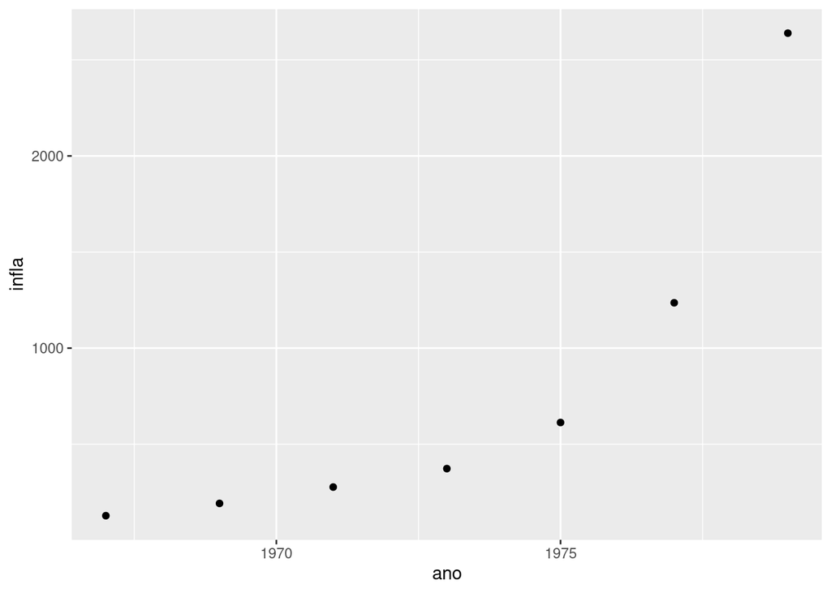

```r
ano <- seq(1967,1979,2)
infla <- c(128,192,277,373,613,1236,2639)

dt <- tibble(ano,infla)


dt %>% ggplot + geom_point(mapping = aes(x = ano, y = infla))
```

```r
cor(dt$ano,dt$infla)
```

```
## [1] 0.8516981
```

Temos uma associaćão forte entre as duas variáveis. Graficamente e tambem peo velor de r

## Exercicio 3

Pesos declarados vs reais

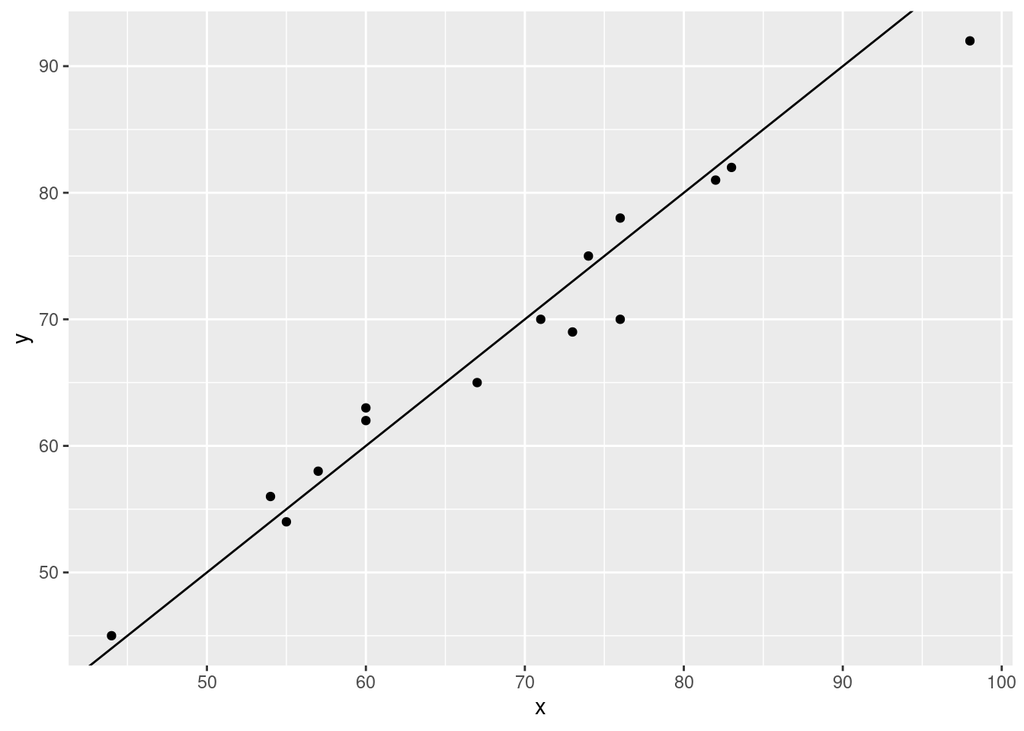

```r
y <- c(82,58,69,70,54,62,92,75,45,81,78,65,56,63,70)
x <- c(83,57,73,76,55,60,98,74,44,82,76,67,54,60,71)

dt3 <- tibble(x,y)

dt3 %>% ggplot + geom_point(aes(x,y)) + geom_abline(intercept=0, slope=1)
```

```r
cor(dt3)
```

```
##           x         y
## x 1.0000000 0.9833176
## y 0.9833176 1.0000000
```

## Exercicio 4

nitrogenio na plantacao de trigo

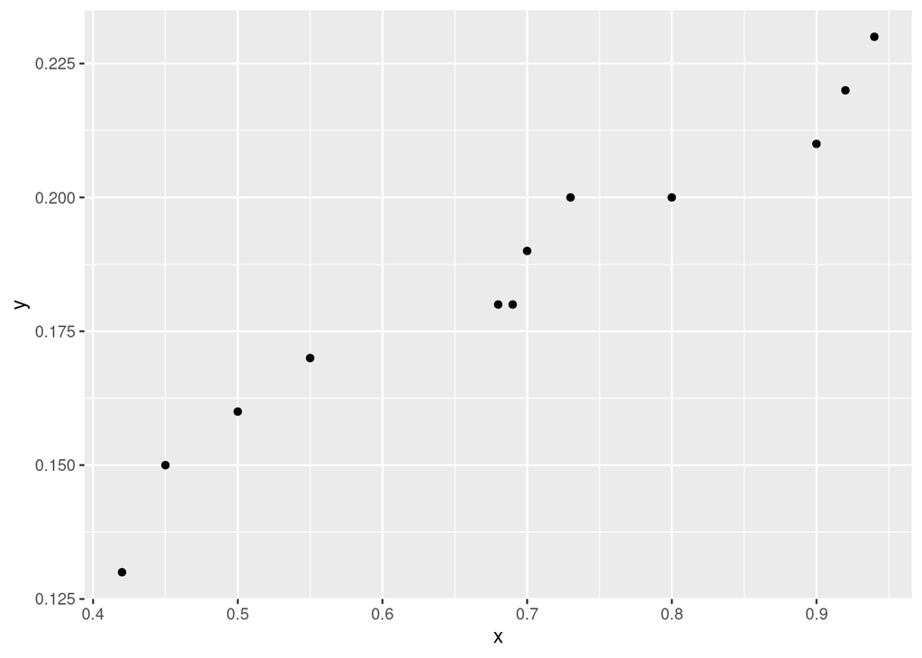

```r
x <- c(42,45,50,55,68,69,70,73,80,90,92,94)
y <- c(13,15,16,17,18,18,19,20,20,21,22,23)

x <- .01*x
y <- .01*y

dt4 <- tibble(x,y)

dt4 %>%  ggplot + geom_point(aes(x,y))
```

```r
cor(dt4)
```

```
##           x         y
## x 1.0000000 0.9752214
## y 0.9752214 1.0000000
```

## Exercicio 5

r aprox 0?

```r
# r > 0 e forte correlacao

cor(iris$Sepal.Length,iris$Petal.Length)
```

```
## [1] 0.8717538
```

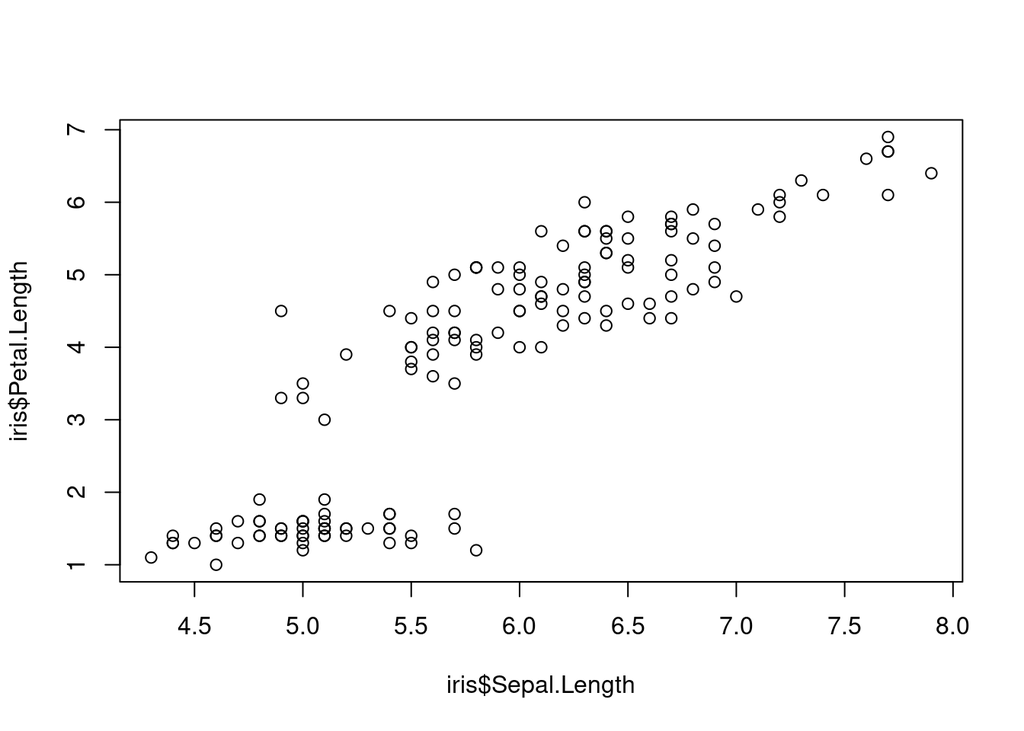

```r
plot(iris$Sepal.Length,iris$Petal.Length)
```

```r
# r aprox 0 numa distr. unif
x <- seq(1,30,1)
y <- runif(30)

cor(x,y)
```

```
## [1] -0.07107403
```

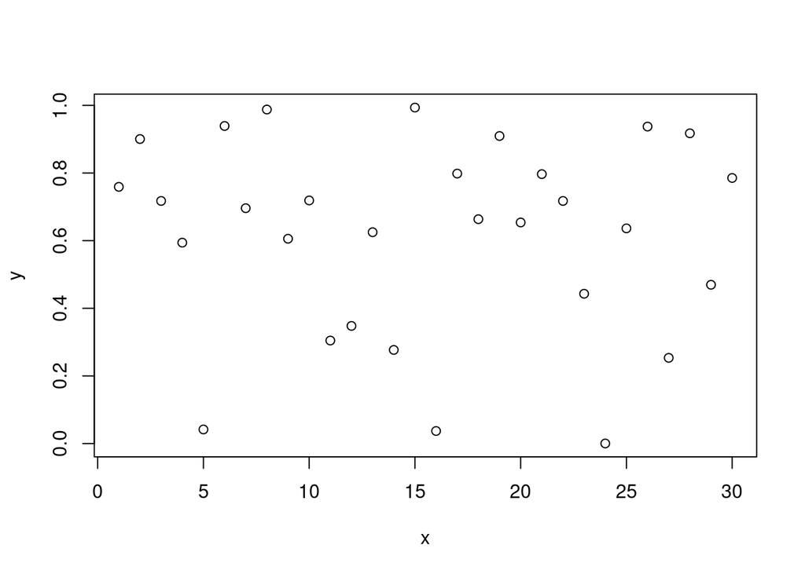

```r
plot(x,y)
```

```r
# correlacao prox de 0 mesmo com assoc linear
x <- seq(1,30,1)
y <- x*cos(pi*x)

cor(x,y)
```

```
## [1] 0.05045621
```

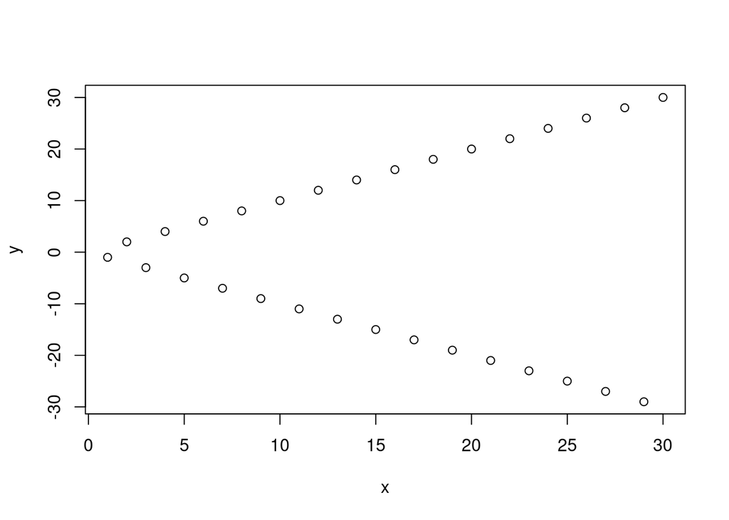

```r
plot(x,y)
```